# regular_trk_rad50_JF.R

jfieberg

Tue Nov 13 22:34:32 2018

Load libraries

```r
library(data.table)
library(RColorBrewer)
library(recurse)
library(tidyverse)
library(lubridate)
library(amt)
library(sp)
library(lme4)
library(splines)
library(mgcv)
options(width=160)
library(knitr)
knitr::opts_chunk$set(error = TRUE)
```

Import dataset (if running in console)

```r
#crane<-read_csv("post_auk_review/processed_data/projected_df.csv")

# If knitting
crane<-read_csv("../processed_data/projected_df.csv")
crane$t<-as.character(crane$t)
crane$t<-as.POSIXct(crane$t, format="%Y-%m-%d %H:%M:%S",
                       tz="America/Chicago")
```

Make track in amt

```r
trk <- mk_track(crane, .x=lon, .y=lat, .t=t, id = id, age=age)
```

```
## .t found, creating `track_xyt`.
```

Lets look at sampling rates for each individual

```r
(timestats<-trk %>% nest(-id) %>% mutate(sr = map(data, summarize_sampling_rate)) %>%
    select(id, sr) %>% unnest)
```

```
## # A tibble: 46 x 10
##    id                         min    q1 median   mean    q3      max       sd     n unit
##    <chr>                    <dbl> <dbl>  <dbl>  <dbl> <dbl>    <dbl>    <dbl> <int> <chr>
##  1 9A  (Santer)              1.72 15      15.7  112.   16.0 395566.   5875.    4534 min
##  2 7C (Helliksen colt 2014)  3    14.9    15.6   26.1  16.1    564.     70.6    771 min
##  3 6C (Rice Lake colt 2014)  1.9  15      15.7  142.   16   394564    5934.    4633 min
##  4 2M (Bagley)               2.67 30.2    30.4  147.   30.6 394640.   6495.   11022 min
##  5 4M (Ogema adult)          0.15 15.5    15.6  109.   15.9 394579.   5564.   15051 min
##  6 5M (Beaulieu adult)       2.7  30.2    30.4  219.   30.9 394741.   8021.    2424 min
##  7 3A  (Barb Wire)           5.48 30.2    30.4 2047.   30.9 500093.  28805.     737 min
##  8 5A (W Staples colt #1)    1.58 15.5    15.6   92.0  15.9 394579.   5116.   17761 min
##  9 1C   (W Staples colt #1)  4     8.55   15.2   13.3  15.5     28.1     5.24    54 hour
## 10 4A (Dower colt)           1.58 15.4    15.5  156.   15.8 394574.   6844.    6627 min
## # ... with 36 more rows
```

```r
print(timestats, n=1000)
```

```
## # A tibble: 46 x 10
##    id                                 min    q1 median   mean    q3      max       sd     n unit
##    <chr>                            <dbl> <dbl>  <dbl>  <dbl> <dbl>    <dbl>    <dbl> <int> <chr>
##  1 9A  (Santer)                     1.72  15      15.7  112.   16.0 395566.   5875.    4534 min
##  2 7C (Helliksen colt 2014)         3     14.9    15.6   26.1  16.1    564.     70.6    771 min
##  3 6C (Rice Lake colt 2014)         1.9   15      15.7  142.   16   394564    5934.    4633 min
##  4 2M (Bagley)                      2.67  30.2    30.4  147.   30.6 394640.   6495.   11022 min
##  5 4M (Ogema adult)                 0.15  15.5    15.6  109.   15.9 394579.   5564.   15051 min
##  6 5M (Beaulieu adult)              2.7   30.2    30.4  219.   30.9 394741.   8021.    2424 min
##  7 3A  (Barb Wire)                  5.48  30.2    30.4 2047.   30.9 500093.  28805.     737 min
##  8 5A (W Staples colt #1)           1.58  15.5    15.6   92.0  15.9 394579.   5116.   17761 min
##  9 1C   (W Staples colt #1)         4      8.55   15.2   13.3  15.5     28.1     5.24    54 hour
## 10 4A (Dower colt)                  1.58  15.4    15.5  156.   15.8 394574.   6844.    6627 min
## 11 6A (Pelican Rapids colt)         1.6   15.5    15.6  119.   15.9 394763.   5793.    9282 min
## 12 5C (Stockyard colt)              0.117 15.4    15.5  105.   15.7 394665.   5493.   15419 min
```

[output cut: 34 more lines]

Most have regular sampling rates (but, there are some short intervals and some that have 30 minute intervals). Lets regularize these to have 1 obs every 30 minutes and only include bursts of observations if there are 3 in a row that are 30 min apart.

```r
regtrk<- trk %>%  nest(-id) %>%
    mutate(regtrk = map(data, function(d) {
      d %>%
        track_resample(rate = minutes(30), tolerance = minutes(3)) %>%
      filter_min_n_burst(min_n = 3)
    })) %>% select(id, regtrk) %>% unnest()
```

Make this a trajectory again

```r
class(regtrk)<-class(trk)
```

Verify we have regular sampling rates

```r
(timestats2<-regtrk %>% nest(-id) %>% mutate(sr = map(data, summarize_sampling_rate)) %>%
    select(id, sr) %>% unnest)
```

```
## # A tibble: 45 x 10
##    id                         min    q1 median  mean    q3     max    sd     n unit
##    <chr>                    <dbl> <dbl>  <dbl> <dbl> <dbl>   <dbl> <dbl> <int> <chr>
##  1 9A  (Santer)              27.0  30.5   31.0 223.   31.6 395581. 8302.  2270 min
##  2 7C (Helliksen colt 2014)  28.9  30.5   31    53.4  31.5    776.  111.   365 min
##  3 6C (Rice Lake colt 2014)  27    30.5   31.1 282.   31.6 395229. 8419.  2308 min
##  4 2M (Bagley)               27.0  30.2   30.4 157.   30.6 394695. 6725. 10301 min
##  5 4M (Ogema adult)          27.1  30.7   31.1 195.   31.4 394579. 7451.  8395 min
##  6 5M (Beaulieu adult)       27.4  30.2   30.4 247.   30.9 394827. 8518.  2152 min
##  7 3A  (Barb Wire)           29.2  30.3   30.4  39.7  30.9   3155.  123.   665 min
##  8 5A (W Staples colt #1)    27.0  31     31.2 171.   31.4 394579. 6967.  9573 min
##  9 4A (Dower colt)           27.3  30.8   30.9 169.   31.2 394635. 6740.  3433 min
## 10 6A (Pelican Rapids colt)  27.0  30.9   31.1 213.   31.4 394763. 7751.  5184 min
## # ... with 35 more rows
```

```r
print(timestats2, n=1000)
```

```
## # A tibble: 45 x 10
##    id                                min    q1 median  mean    q3      max       sd     n unit
##    <chr>                           <dbl> <dbl>  <dbl> <dbl> <dbl>    <dbl>    <dbl> <int> <chr>
##  1 9A  (Santer)                     27.0  30.5   31.0 223.   31.6 395581.   8302.    2270 min
##  2 7C (Helliksen colt 2014)         28.9  30.5   31    53.4  31.5    776.    111.     365 min
##  3 6C (Rice Lake colt 2014)         27    30.5   31.1 282.   31.6 395229.   8419.    2308 min
##  4 2M (Bagley)                      27.0  30.2   30.4 157.   30.6 394695.   6725.   10301 min
##  5 4M (Ogema adult)                 27.1  30.7   31.1 195.   31.4 394579.   7451.    8395 min
##  6 5M (Beaulieu adult)              27.4  30.2   30.4 247.   30.9 394827.   8518.    2152 min
##  7 3A  (Barb Wire)                  29.2  30.3   30.4  39.7  30.9   3155.    123.     665 min
##  8 5A (W Staples colt #1)           27.0  31     31.2 171.   31.4 394579.   6967.    9573 min
##  9 4A (Dower colt)                  27.3  30.8   30.9 169.   31.2 394635.   6740.    3433 min
## 10 6A (Pelican Rapids colt)         27.0  30.9   31.1 213.   31.4 394763.   7751.    5184 min
## 11 5C (Stockyard colt)              27    30.9   31.0 206.   31.3 395313.   7685.    7885 min
## 12 5E (Linden Kologi colt #2)       27.3  30.4   31.5  30.5  31.6     31.6     2.14     4 min
```

[output cut: 33 more lines]

## Calculate various summary statistics from the regularlized track

Now, lets calculate step length, turn angles, angles relative to due N, and net-squared displacement for each individual.

```r
trk2<-regtrk %>% nest(-id) %>%
  mutate(dir_abs = map(data, direction_abs,full_circle=TRUE, zero="N"),
         dir_rel = map(data, direction_rel),
         sl = map(data, step_lengths),
         nsd_=map(data, nsd))%>%unnest()
```

Add on the week, month, year, and hour of the observation

```r
trk3<-trk2%>%
  mutate(
    week=week(t_),
    month = month(t_, label=TRUE),
    year=year(t_),
    hour = hour(t_)
  )
```

Get rid of individuals with little data

```r
trange <- function(x) {
  max(x)- min(x)
}
nt<-trk3 %>% group_by(id) %>% summarize(rangets=trange(t_))

large.n.cranes<-nt %>% filter(rangets > 90)
large.n.cranes %>% select(id)
```

```
## # A tibble: 31 x 1
##    id
##    <chr>
##  1 0C (Callaway colt 2014)
##  2 0J (Waubun adult #2)
##  3 0K Deglman #1
##  4 0M (N of Mud Lake)
##  5 1J (Santiago #3)
##  6 1K (Melby colt #2)
##  7 2A (Helliksen July 2015 colt)
##  8 2M (Bagley)
##  9 3K (Rasmussen adult)
## 10 4A (Dower colt)
## # ... with 21 more rows
```

```r
trk4<-trk3[trk3$id %in% large.n.cranes$id,]
trk4<-trk4[trk4$id %in% c("3A (Barb Wire)", "7A (Hackensack)", "8J (Inman colt #1)") !=TRUE,]
class(trk4)<-class(trk)
```

```r
trk4 %>% filter(nsd_>200000000)
```

```
## # A tibble: 0 x 14
## # ... with 14 variables: id <chr>, dir_abs <dbl>, dir_rel <dbl>, sl <dbl>, nsd_ <dbl>, x_ <dbl>, y_ <dbl>, t_ <dttm>, age <chr>, burst_ <dbl>, week <dbl>,
## #   month <ord>, year <dbl>, hour <int>
```

```r
trk4 <- trk4 %>% filter(nsd_<200000000)
```

```r
cr<-trk4
cr.sp<-SpatialPoints(cr[c('x_','y_')], proj4string = CRS("+proj=longlat +ellps=WGS84"))
#Albers Equal Area projection with specified meridians for boundaries
cr.sp<-spTransform(cr.sp, CRS("+proj=aea +lat_1=29.5 +lat_2=45.5 +lat_0=37.5 +lon_0=-96 +x_0=0 +y_0=0 +ellps=GRS80 +datum=NAD83 +units=m +no_defs "))
colnames(cr)[6:7]<-c('lon', 'lat')
cr<-cbind(cr, cr.sp@coords)
```

Get recurse stats

```r
cr$id<-as.factor(cr$id)
cr.r = cr[, c("x_", "y_",  't_', 'id')]
```

Look at reasonable radius based on step length

```r
trk.cr <- mk_track(cr.r, .x=x_, .y=y_, .t=t_, id = id)
```

```
## .t found, creating `track_xyt`.
```

```r
trk2.cr<-trk.cr %>% nest(-id) %>%
  mutate(sl = map(data, step_lengths),
         nsd_=map(data, nsd))%>%unnest()
summary(trk2.cr$sl)  # this makes it look like 50 may be OK
```

```
##     Min.  1st Qu.   Median     Mean  3rd Qu.     Max.     NA's
##      0.0     14.1     62.9    366.0    190.5 373520.2       31
```

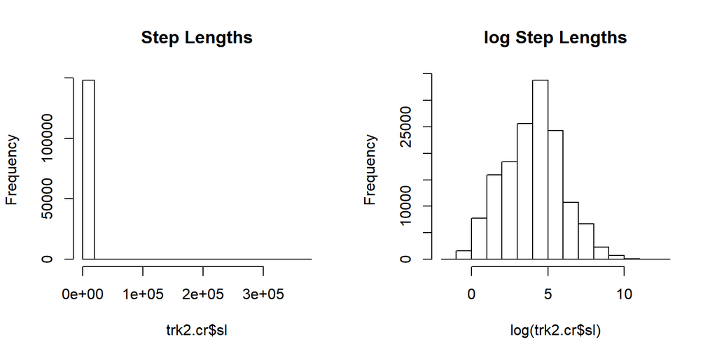

```r
par(mfrow=c(1,2))
hist(trk2.cr$sl, main="Step Lengths")
hist(log(trk2.cr$sl), main="log Step Lengths")
```

```r
exp(5)
```

```
## [1] 148.4132
```

```r
par(mfrow=c(1,1))
```

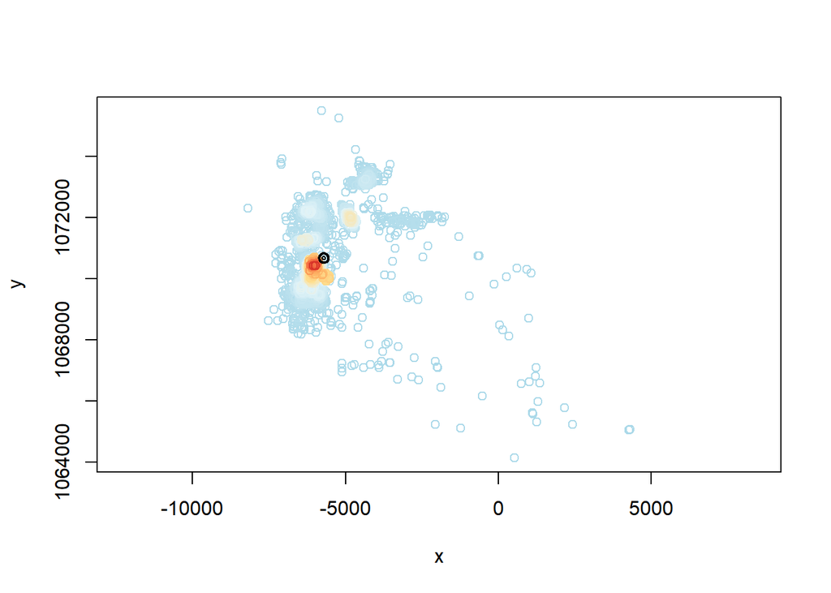

```r
i<-10
unique.ids<-unique(cr.r$id)
tmpdat<-cr.r%>%filter(id==unique.ids[i])
tmpsl<-cr%>%filter(id==unique.ids[i])%>%select(sl)
tmprecurse<-getRecursions(tmpdat, 150, verbose = TRUE)
plot(tmprecurse, tmpdat)
drawCircle(mean(tmpdat$x_), mean(tmpdat$y_), 50) # original circle...small point
drawCircle(mean(tmpdat$x_), mean(tmpdat$y_), 150, lwd=2) # original circle...small point
```

```r
cr_recurse<-NULL
for(i in 1:length(unique.ids)){
  tmpdat<-cr.r%>%filter(id==unique.ids[i])
  tmpsl<-cr%>%filter(id==unique.ids[i])%>%select(sl)
  tmprecurse<-getRecursions(tmpdat, 150, verbose = TRUE)
  cr_recurse<-rbind(cr_recurse, data.frame(id=tmpdat$id, timestamp=tmpdat$t_,
                                          revisits=tmprecurse$revisits,
                                          durations=tmprecurse$residenceTime,
                                          timeunits=tmprecurse$timeunits,
                                          radius='50_meters',
                                          sl=tmpsl,x=tmpdat$x, y=tmpdat$y))

}
```

Get adult juv and add to data frame

```r
adult.list<-c("0J (Waubun adult #2)", "0K Deglman #1","1J (Santiago #3)" ,
              "2C (Melby adult)" , "2M (Bagley)" , "3C (Larson adult #2)" ,
              "3E (Wambach adult)" , "3K (Rasmussen adult)",  "3M  (Callaway adult)" ,
              "4E Larson adult #1" , "4J (Santiago #1)",  "4K (Waubun #1)" ,  "4M (Ogema adult)" ,
              "5J (Deglman #3)" , "5K (Helliksen July adult 2015)", "5M (Beaulieu adult)" ,
              "6E (Linden-Kologi)", "8K (Deglman #2)","8M (Stockyard adult)",
              "9A  (Santer)" , "9C (Helliksen adult April 2015)","9K (Santiago #2)" ,"9M (Inman adult)" )
cr_recurse<-mutate(cr_recurse, age=ifelse(id%in%adult.list, "adult", "colt"))
cr_recurse$age<-as.factor(cr_recurse$age)
```

add day, julian day, year

```r
cr_recurse$day<-day(cr_recurse$timestamp)
cr_recurse$juliand<-yday(cr_recurse$timestamp)
cr_recurse$yr<-year((cr_recurse$timestamp))
```

Summary of revisitation statistics and durations

- these are definitely skewed distributions!
- Will want to think about modeling on log scale
- also have counts (revisits), but really large counts….

```r
summary(cr_recurse$revisits)
```

```
##    Min. 1st Qu.  Median    Mean 3rd Qu.    Max.
##    1.00   12.00   39.00   75.09  106.00  584.00
```

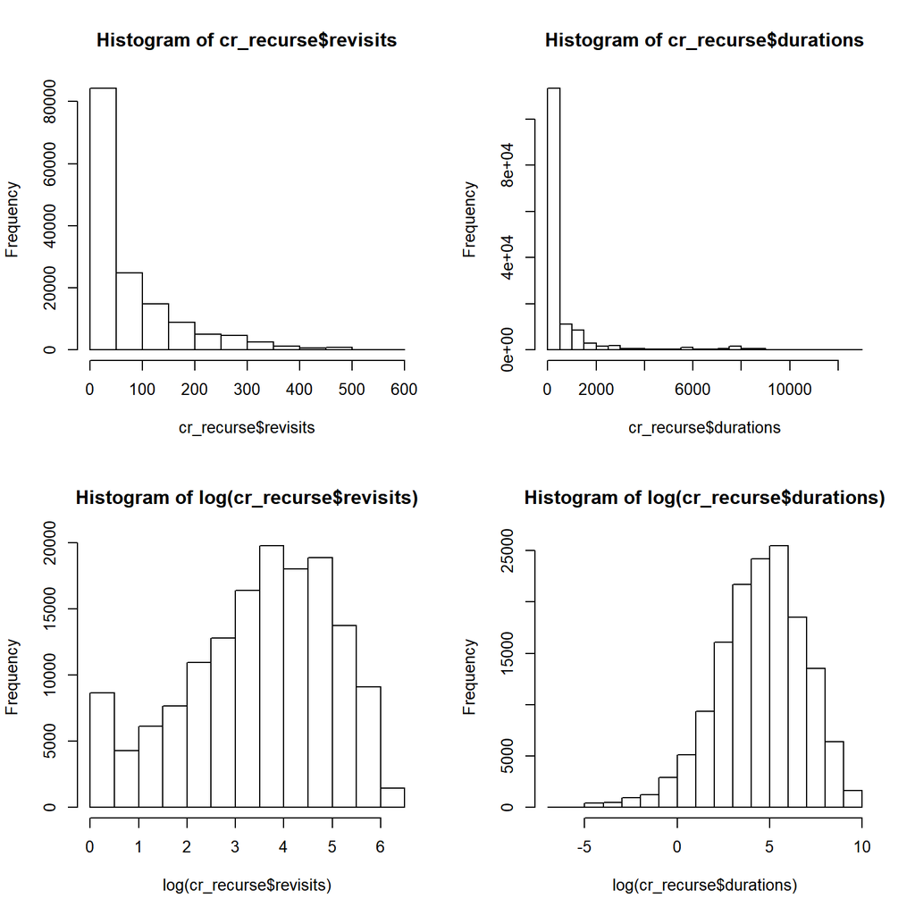

```r
cr_recurse<-cr_recurse[cr_recurse$revisits<1200,]
par(mfrow=c(2,2))
hist(cr_recurse$revisits)
hist(cr_recurse$durations)

hist(log(cr_recurse$revisits))
hist(log(cr_recurse$durations))
```

```r
par(mfrow=c(1,1))
```

Lets look at some plots of how things vary by adult/juv and over time

Order by adult/juv

```r
cr_recurse <-mutate(cr_recurse, Subject = reorder(age, id))
```

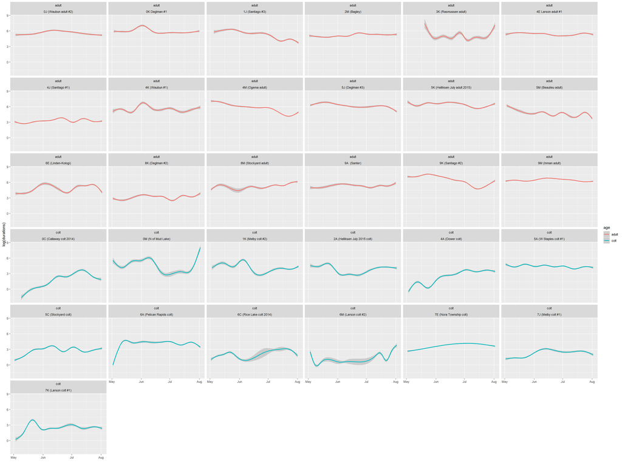

```r
ggplot(cr_recurse, aes(x=as.Date(juliand, origin = as.Date("2018-01-01")),
                       y=log(durations), colour=age))  +
  facet_wrap(~Subject+id)+geom_smooth()+
  scale_x_date(date_labels = "%b")+ xlab("")
```

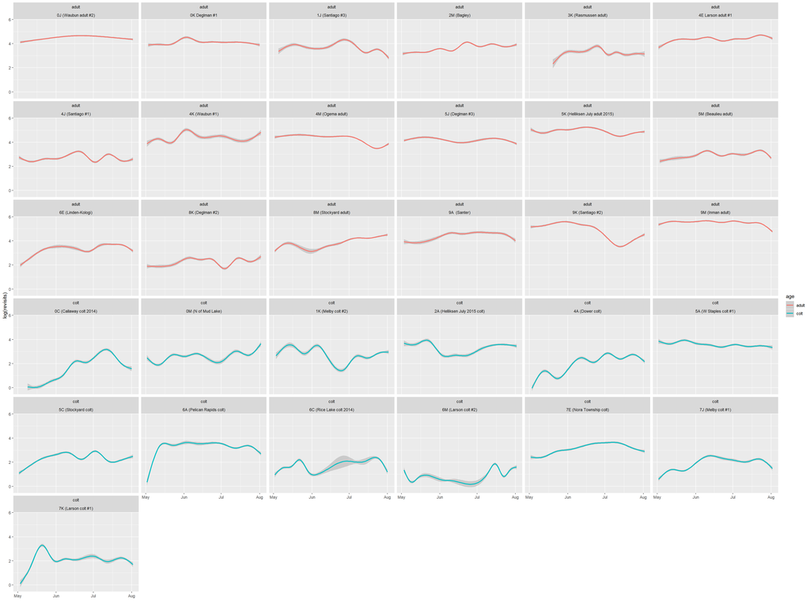

```r
ggplot(cr_recurse, aes(x=as.Date(juliand, origin = as.Date("2018-01-01")),
                       y=log(revisits), colour=age)) +
  facet_wrap(~Subject + id)+geom_smooth()+
  scale_x_date(date_labels = "%b")+ xlab("")
```

These are not all that wigly for each individual… Could almost get away with something like:

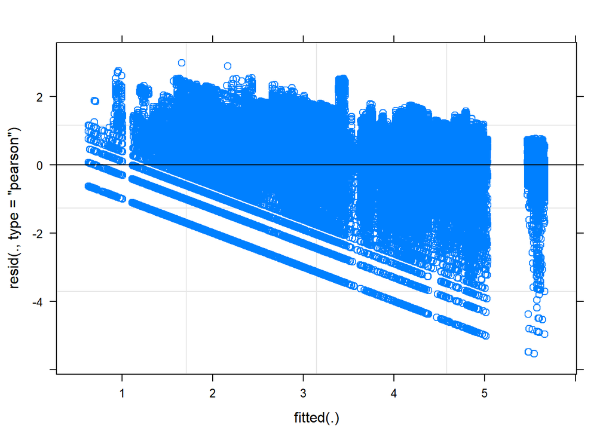

```r
m1<-lmer(log(revisits)~age+juliand + age*juliand+ (1|id/yr), data=cr_recurse, REML=T)
plot(m1)
```

```r
summary(m1)
```

```
## Linear mixed model fit by REML ['lmerMod']
## Formula: log(revisits) ~ age + juliand + age * juliand + (1 | id/yr)
##    Data: cr_recurse
##
## REML criterion at convergence: 435732.3
##
## Scaled residuals:
##     Min      1Q  Median      3Q     Max
## -5.2704 -0.5088  0.2009  0.6654  2.8404
##
## Random effects:
##  Groups   Name        Variance Std.Dev.
##  yr:id    (Intercept) 0.3181   0.5640
##  id       (Intercept) 0.4670   0.6833
##  Residual             1.1064   1.0519
## Number of obs: 148047, groups:  yr:id, 91; id, 31
##
## Fixed effects:
##                   Estimate Std. Error t value
## (Intercept)      4.1972195  0.1819011   23.07
## agecolt         -2.9998985  0.2823760  -10.62
## juliand         -0.0016117  0.0001485  -10.86
## agecolt:juliand  0.0089284  0.0002274   39.27
##
## Correlation of Fixed Effects:
##             (Intr) ageclt julind
## agecolt     -0.644
## juliand     -0.143  0.092
## ageclt:jlnd  0.094 -0.141 -0.653
```

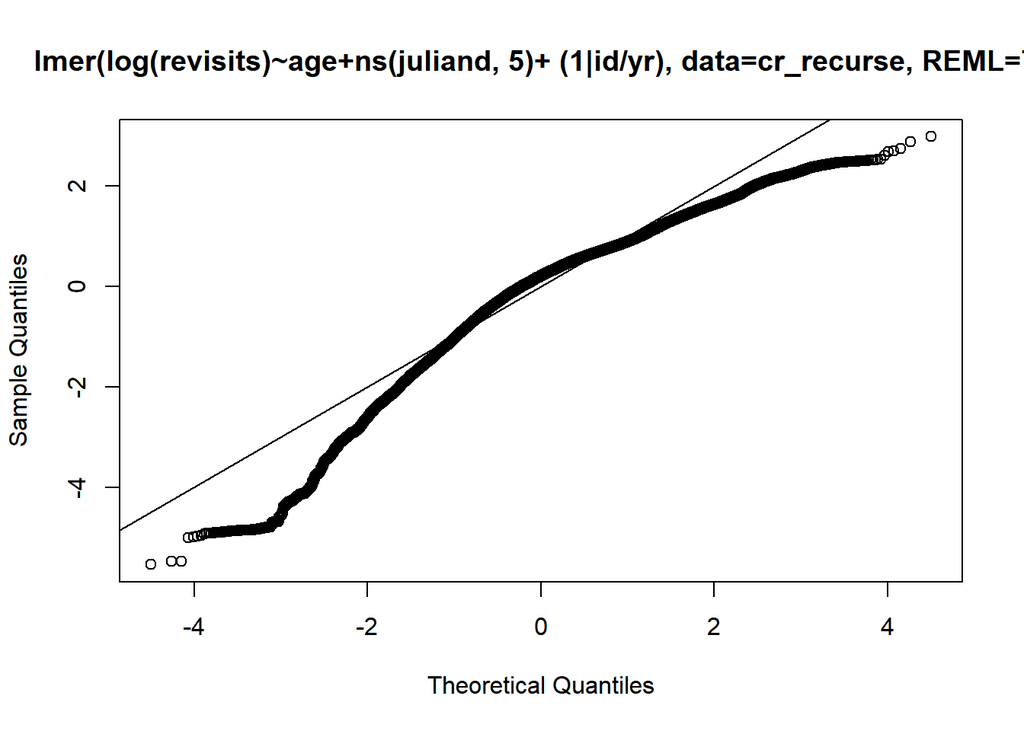

```r
qqnorm(resid(m1), main='lmer(log(revisits)~age+ns(juliand, 5)+ (1|id/yr), data=cr_recurse, REML=T)')
abline(0,1)
```

Or, consider fitting using a count distribution (negative binomial), where the effects of covariates enter on the log scale. Here, it can help to scale julian date when fitting.

```r
cr_recurse$sjd<-scale(cr_recurse$juliand)
m2<-glmer.nb(revisits~age+sjd + age*sjd+  (1|id), data=cr_recurse, REML=T)
```

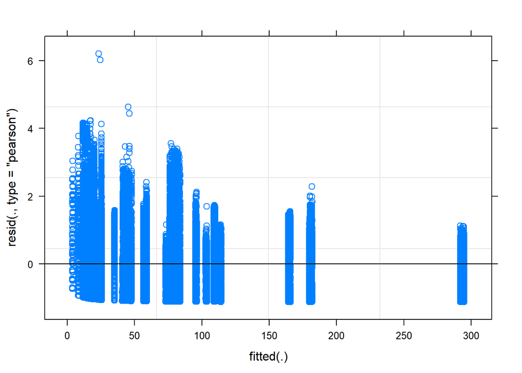

```r
plot(m2)
```

```r
summary(m2)
```

```
## Generalized linear mixed model fit by maximum likelihood (Laplace Approximation) ['glmerMod']
##  Family: Negative Binomial(1.2909)  ( log )
## Formula: revisits ~ age + sjd + age * sjd + (1 | id)
##    Data: cr_recurse
##
##       AIC       BIC    logLik  deviance  df.resid
## 1459698.5 1459757.9 -729843.2 1459686.5    148041
##
## Scaled residuals:
##     Min      1Q  Median      3Q     Max
## -1.1298 -0.7376 -0.1614  0.5755  6.2136
##
## Random effects:
##  Groups Name        Variance Std.Dev.
##  id     (Intercept) 0.5891   0.7675
## Number of obs: 148047, groups:  id, 31
##
## Fixed effects:
##              Estimate Std. Error z value Pr(>|z|)
## (Intercept)  4.299971   0.168156  25.571  < 2e-16 ***
## agecolt     -1.284152   0.252108  -5.094 3.51e-07 ***
## sjd         -0.003106   0.003278  -0.948    0.343
## agecolt:sjd  0.032389   0.005041   6.426 1.31e-10 ***
## ---
## Signif. codes:  0 '***' 0.001 '**' 0.01 '*' 0.05 '.' 0.1 ' ' 1
##
## Correlation of Fixed Effects:
##             (Intr) ageclt sjd
## agecolt     -0.612
## sjd         -0.002  0.001
## agecolt:sjd  0.001 -0.001 -0.650
```

```r
#b splines
#m4<-gam(revisits~age+s(juliand, by=age), data=cr_recurse)
#plot(m4)
```

We fit similar models using gam, but this also allows us to allow the effect of julian date to vary smoothly

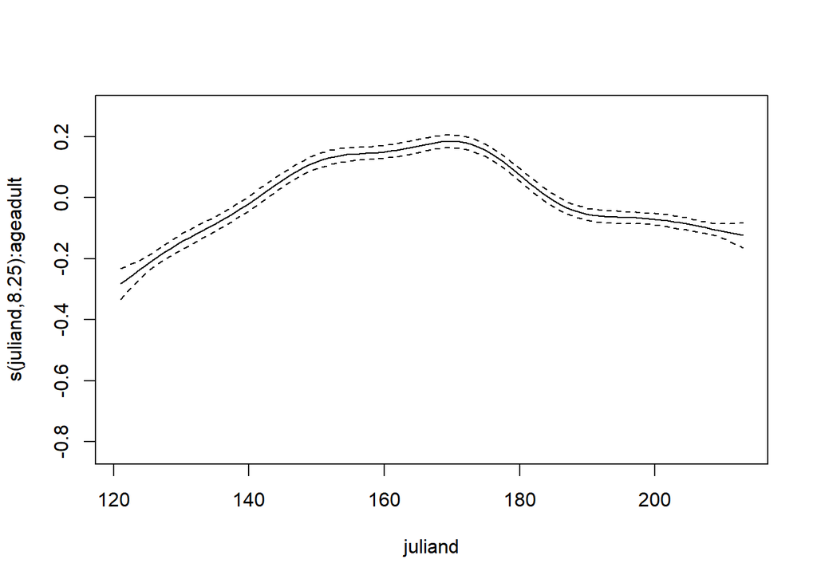

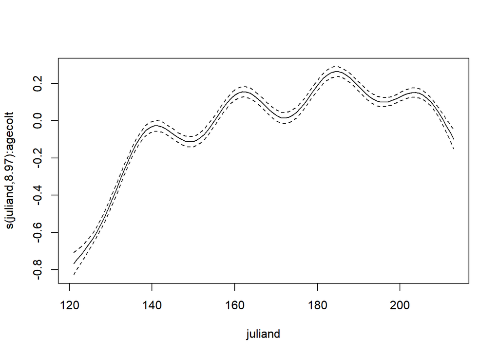

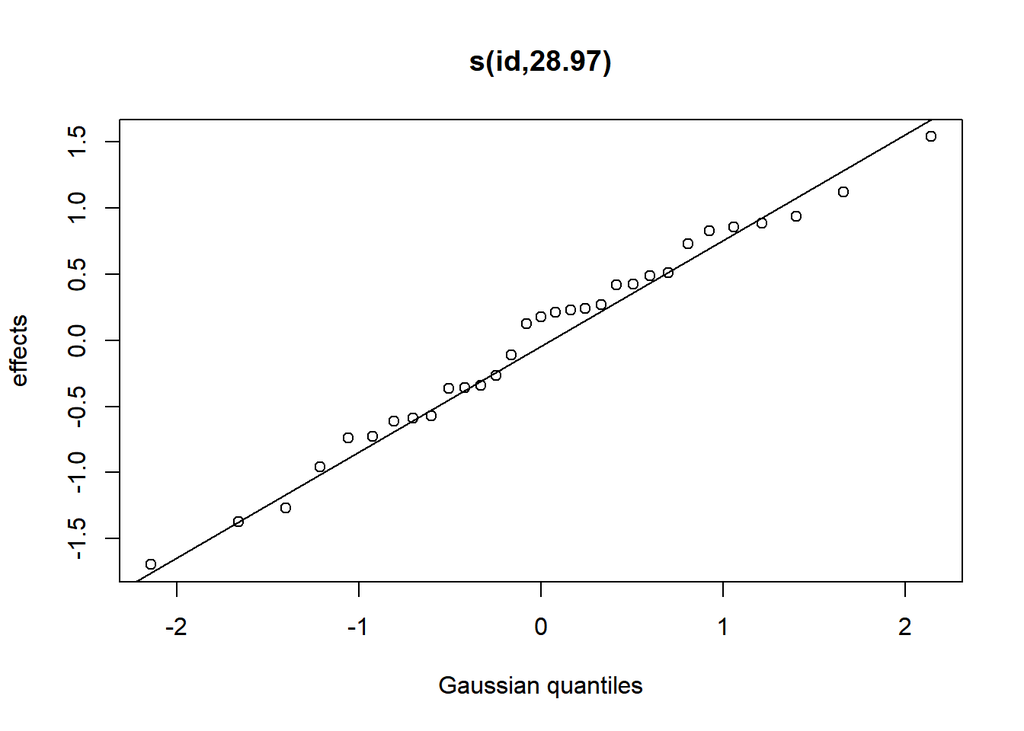

```r
m3<-gam(log(revisits)~age+s(juliand, by=age)+s(id, bs="re"), data=cr_recurse)
plot(m3)
```

```r
summary(m3)
```

```
##
## Family: gaussian
## Link function: identity
##
## Formula:
## log(revisits) ~ age + s(juliand, by = age) + s(id, bs = "re")
##
## Parametric coefficients:
##             Estimate Std. Error t value Pr(>|t|)
## (Intercept)   3.9649     0.1518  26.123  < 2e-16 ***
## agecolt      -1.5310     0.2344  -6.532 6.51e-11 ***
## ---
## Signif. codes:  0 '***' 0.001 '**' 0.01 '*' 0.05 '.' 0.1 ' ' 1
##
## Approximate significance of smooth terms:
##                        edf Ref.df      F p-value
## s(juliand):ageadult  8.247  8.844  107.7  <2e-16 ***
## s(juliand):agecolt   8.965  9.000  272.6  <2e-16 ***
## s(id)               28.974 29.000 2213.4  <2e-16 ***
## ---
## Signif. codes:  0 '***' 0.001 '**' 0.01 '*' 0.05 '.' 0.1 ' ' 1
##
## R-sq.(adj) =  0.447   Deviance explained = 44.7%
## GCV = 1.3261  Scale est. = 1.3257    n = 148047
```

Gam also appears to allow fitting of negative binomial models. This may be one to consider…

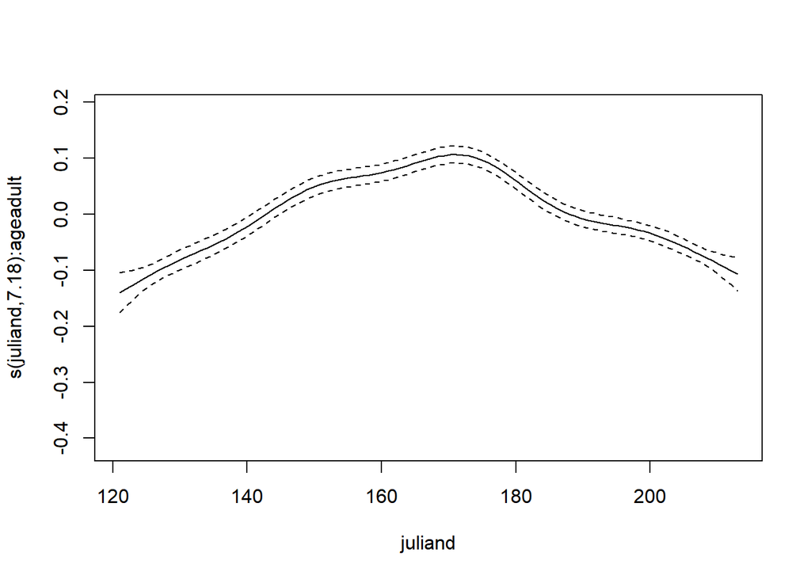

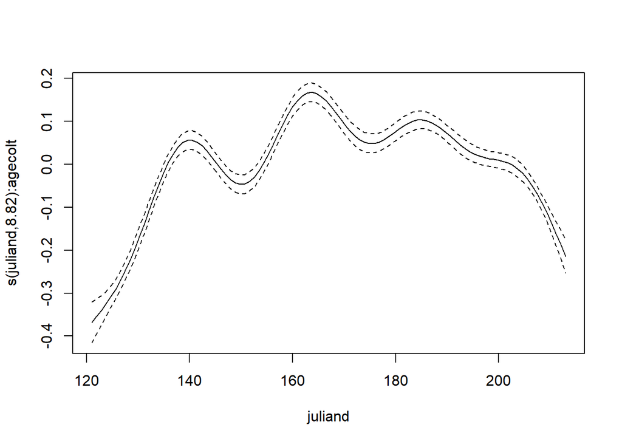

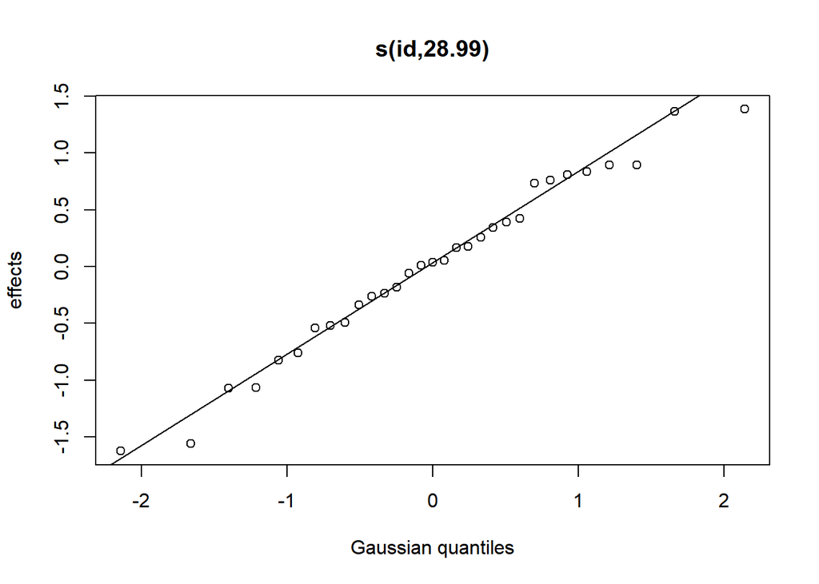

```r
m4<-gam(revisits~age+s(juliand, by=age)+s(id, bs="re"), family=nb(), data=cr_recurse)
plot(m4)
```

```r
summary(m4)
```

```
##
## Family: Negative Binomial(1.302)
## Link function: log
##
## Formula:
## revisits ~ age + s(juliand, by = age) + s(id, bs = "re")
##
## Parametric coefficients:
##             Estimate Std. Error z value Pr(>|z|)
## (Intercept)   4.2957     0.1866   23.02  < 2e-16 ***
## agecolt      -1.2768     0.2882   -4.43 9.41e-06 ***
## ---
## Signif. codes:  0 '***' 0.001 '**' 0.01 '*' 0.05 '.' 0.1 ' ' 1
##
## Approximate significance of smooth terms:
##                        edf Ref.df   Chi.sq p-value
## s(juliand):ageadult  7.179  8.211    511.2  <2e-16 ***
## s(juliand):agecolt   8.819  8.990   1017.0  <2e-16 ***
## s(id)               28.989 29.000 100905.2  <2e-16 ***
## ---
## Signif. codes:  0 '***' 0.001 '**' 0.01 '*' 0.05 '.' 0.1 ' ' 1
##
## R-sq.(adj) =  0.553   Deviance explained = 47.1%
## -REML = 7.2918e+05  Scale est. = 1         n = 148047
```

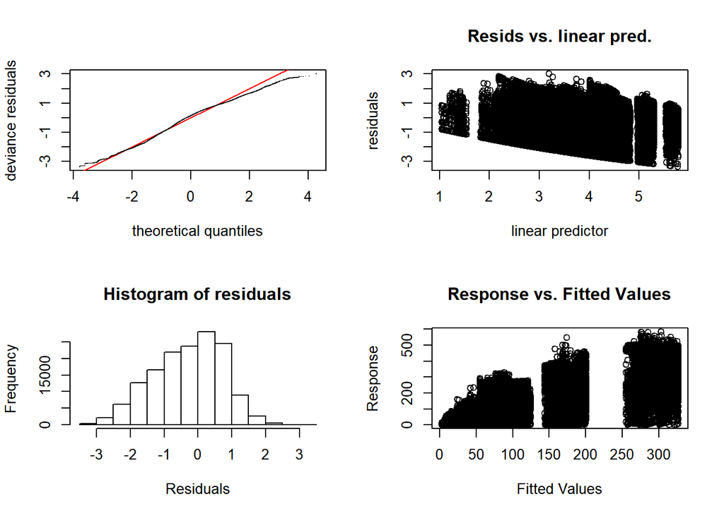

```
##
## Method: REML   Optimizer: outer newton
## full convergence after 7 iterations.
## Gradient range [-1.686327e-05,0.007879212]
## (score 729180.7 & scale 1).
## Hessian positive definite, eigenvalue range [1.462486,77666.01].
## Model rank =  51 / 51
##
## Basis dimension (k) checking results. Low p-value (k-index<1) may
## indicate that k is too low, especially if edf is close to k'.
##
##                        k'   edf k-index p-value
## s(juliand):ageadult  9.00  7.18     0.9    0.12
## s(juliand):agecolt   9.00  8.82     0.9    0.11
## s(id)               31.00 28.99      NA      NA
```

```r
gam.check(m4)
```

NOte, it is only approporiate to compare models fit to the same response

- comparisons of log(revisits) and revisits are not appropriate
- also, different fitting functions may not give same AIC for same model

So, I did not compare models using AIC. I think we want to pick a reasonable model based on what we think is appropriate & then just do some model checking to make sure assumptions are reasonably met.

Could also look to fit models to duration

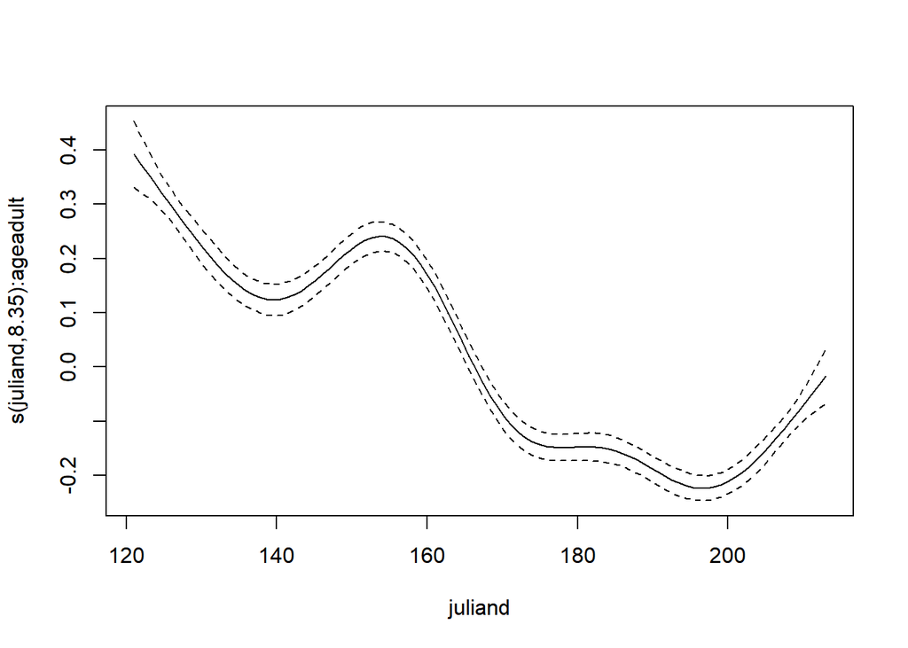

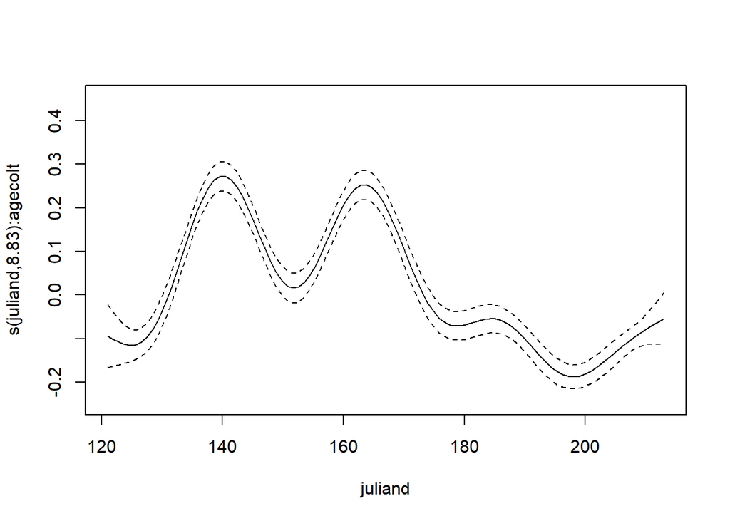

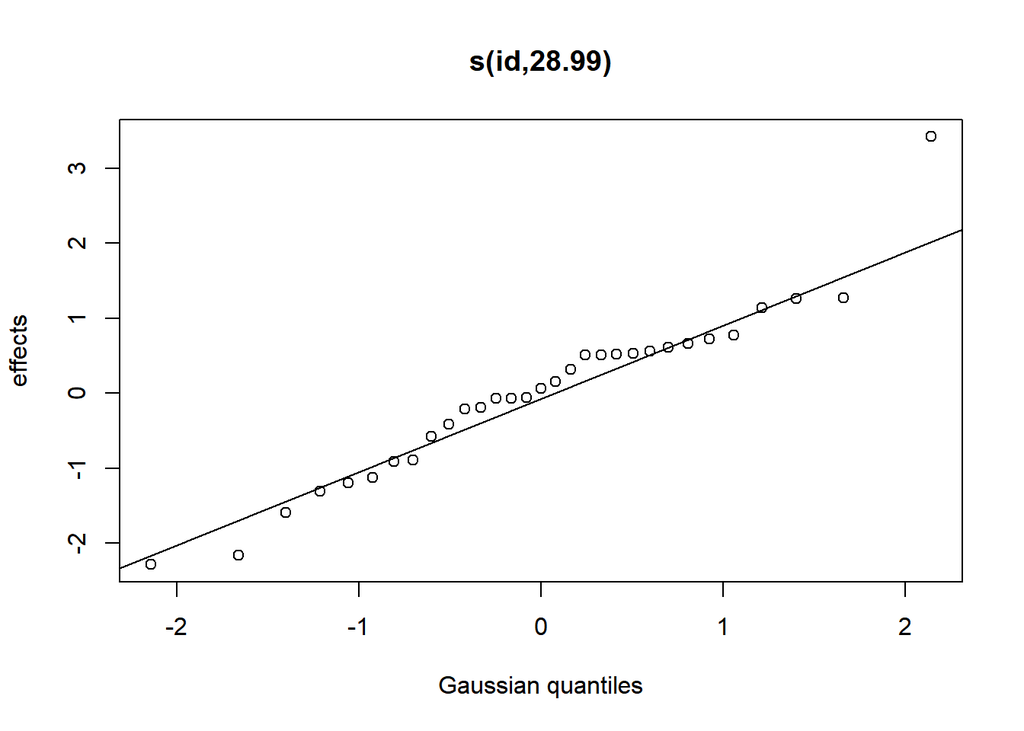

```r
d7<-gam(durations~age+s(juliand, by=age)+s(id, bs="re"), family=nb(), data=cr_recurse)
plot(d7)
```

```r
gam.vcomp(d7)
```

```
##
## Standard deviations and 0.95 confidence intervals:
##
##                         std.dev       lower      upper
## s(juliand):ageadult 0.006485451 0.003819787 0.01101137
## s(juliand):agecolt  0.016197348 0.009608197 0.02730523
## s(id)               1.135951207 0.881800177 1.46335324
##
## Rank: 3/3
```

```r
summary(d7)
```

```
##
## Family: Negative Binomial(0.521)
## Link function: log
##
## Formula:
## durations ~ age + s(juliand, by = age) + s(id, bs = "re")
##
## Parametric coefficients:
##             Estimate Std. Error z value Pr(>|z|)
## (Intercept)   6.3359     0.2678  23.659  < 2e-16 ***
## agecolt      -1.8438     0.4135  -4.458 8.26e-06 ***
## ---
## Signif. codes:  0 '***' 0.001 '**' 0.01 '*' 0.05 '.' 0.1 ' ' 1
##
## Approximate significance of smooth terms:
##                        edf Ref.df  Chi.sq p-value
## s(juliand):ageadult  8.350  8.882  1419.1  <2e-16 ***
## s(juliand):agecolt   8.829  8.991   634.6  <2e-16 ***
## s(id)               28.988 29.000 94448.2  <2e-16 ***
## ---
## Signif. codes:  0 '***' 0.001 '**' 0.01 '*' 0.05 '.' 0.1 ' ' 1
##
## R-sq.(adj) =  0.223   Deviance explained = 39.1%
## -REML = 9.713e+05  Scale est. = 1         n = 148047
```

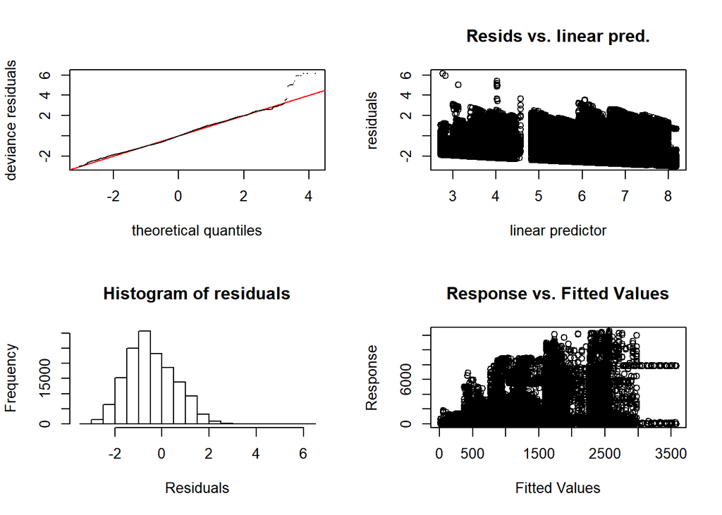

```
##
## Method: REML   Optimizer: outer newton
## full convergence after 12 iterations.
## Gradient range [0.0004637799,0.4850344]
## (score 971302 & scale 1).
## Hessian positive definite, eigenvalue range [3.427069,102168.1].
## Model rank =  51 / 51
##
## Basis dimension (k) checking results. Low p-value (k-index<1) may
## indicate that k is too low, especially if edf is close to k'.
##
##                        k'   edf k-index p-value
## s(juliand):ageadult  9.00  8.35     0.8   0.045 *
## s(juliand):agecolt   9.00  8.83     0.8   0.050 *
## s(id)               31.00 28.99      NA      NA
## ---
## Signif. codes:  0 '***' 0.001 '**' 0.01 '*' 0.05 '.' 0.1 ' ' 1
```

```r
gam.check(d7)
```

For more on gams, see:

- https://stat.ethz.ch/R-manual/R-devel/library/mgcv/html/negbin.html
- https://stat.ethz.ch/R-manual/R-devel/library/mgcv/html/random.effects.html

And more on recurse

- https://cran.r-project.org/web/packages/recurse/vignettes/recurse.html